# Keywords-in-Context and Dictionaries

Solutions

Tom Paskhalis

29 November, 2018

```r
# Load libraries
library("readr")
library("dplyr")
library("stringr")
library("lubridate")
library("quanteda")
```

## Challenge 2

**Easy mode** Explore the context of the words *gun* and *firearm* with the `kwic()` function. Are there any issues with the default setting? Treat them as `glob` to capture plural forms.

```r
guns <- quanteda::kwic(corpus115, "gun*", window = 5, valuetype = "glob")
head(guns, 50)
```

```
##
##     [text16, 877]  silence our voices for commonsense |   gun   |
##    [text128, 402]         simplest kinds of things on |   gun   |
##    [text128, 434]        asking patients if there are |  guns   |
##    [text128, 473]                 to ask if there are |  guns   |
##    [text128, 485]                  gone so far in the |   gun   |
##    [text128, 496]      Americans own over 320 million |  guns   |
##    [text128, 573]                    be able to buy a |   gun   |
##    [text128, 687]      couldn't get on airplanes have |  guns   |
##    [text168, 194]          last year over inaction on |   gun   |
##   [text168, 1881]         the public health crisis of |   gun   |
##    [text172, 200]          the people to bring strong |   gun   |
##    [text174, 152]          that silences the call for |   gun   |
##    [text177, 216]                 you could not get a |   gun   |
##    [text180, 137]         this public health issue of |   gun   |
##    [text180, 250]         the floor that would reduce |   gun   |
##    [text180, 543]            big public health issue: |   gun   |
##   [text180, 2131]            just about the sit-in on |  guns   |
##     [text184, 69]        taking action to address the |   gun   |
##    [text193, 165]          enacted in response to the |   gun   |
##    [text193, 178]          to address the epidemic of |   gun   |
##   [text350, 2715]          that cities that have more |   gun   |
##   [text350, 2770]           that cities with the most |   gun   |
##   [text350, 2799]           , been killed, themassive |   gun   |
##   [text350, 2814]             got a massive number of |   gun   |
##     [text490, 39]              Delaware: George Read, | Gunning |
##    [text558, 101]                 up in a world where |   gun   |
##    [text558, 137] universal background checks, making |   gun   |
##    [text558, 203]        to make progress on reducing |   gun   |
##    [text603, 468]                then you can't buy a |   gun   |
##     [text976, 47]      congressional district, when a | gunman  |
##     [text976, 53]     mercilessly unleashed a hail of | gunfire |
##   [text1061, 101]    well-worn routine in response to |   gun   |
##   [text1061, 198]      silent during this epidemic of |   gun   |
##    [text1546, 72]        Second Amendment rights. The |   Gun   |
##  [text1555, 1457]  by unknown assailants with machine |  guns   |
##   [text1815, 119]        trying to bring attention to |   gun   |
##   [text2083, 398]          We got ambushed by machine |  gun.I  |
##   [text2325, 689]             is no mention of ending |   gun   |
##   [text2325, 695]     violence or looking at sensible |   gun   |
```

[output cut: 47 more lines]

```
##  violence in this country.
##  got shot in the arm
##  violence or looking at sensible
##  safety regulations or laws,
##  Violence Reduction Resources Act,
##  wrong. In particular,
##  , but he was because
##  dealer was so easy and
##  violence prevention that I have
##  violence in their communities.
##  suddenly rang out while three
##  in order to protect his
##  , now less than 5
##  down and murdered in the
##  -- that is outlawed
```

```r
firearms <- quanteda::kwic(corpus115, "firearm*", window = 5, valuetype = "glob")
head(firearms, 50)
```

```
##
##   [text1546, 143]  of Active-Duty servicemembers to purchase | firearms |
##   [text2977, 521]                if they attempt to purchase | firearms |
##   [text3182, 165]                        also unfit to own a | firearm  |
##  [text3184, 1158]                   rule is intended to keep | firearms |
##  [text3184, 1203] identify individuals ineligible to possess | firearms |
##   [text3195, 530]                          possess, or use a | firearm  |
##   [text3203, 203]                the NICS database and their | firearms |
##   [text3203, 213]                       their right to own a | firearm  |
##    [text3206, 98]                 low wages to obtain deadly | firearms |
##   [text3206, 221]   prohibited from purchasing or possessing | firearms |
##   [text3206, 268]                      goal is to weaken our | firearms |
##   [text3206, 451]          rounds of ammunition from Roanoke | Firearms |
##   [text3206, 503]          nonetheless allowed to purchase a | firearm  |
##   [text3206, 740]  categories of individuals from possessing | firearms |
##   [text3206, 788] Prevention Act requires federally licensed | firearms |
##   [text3206, 818]         law from purchasing and possessing | firearms |
##   [text3206, 951]   passing background checks and purchasing | firearms |
##  [text3206, 1233]          law from purchasing or possessing | firearms |
##   [text3393, 179]          Second Amendment right to possess | firearms |
##   [text3393, 299]                   their right to possess a | firearm  |
##   [text3393, 410]                     his right to possess a | firearm  |
##   [text3393, 469]                     the right to possess a | firearm  |
##   [text3393, 546]                   his ability to possess a | firearm  |
##   [text3395, 164]  prohibited from purchasing and possessing | firearms |
##   [text3395, 565]       should be prohibited from possessing | firearms |
##   [text3395, 912]              to a longstanding category of | firearms |
##  [text3395, 1195]                         , possess or use a | firearm  |
##  [text3395, 1439]                         , possess or use a | firearm  |
##  [text3395, 1663]                    safely possess or own a | firearm  |
##  [text3395, 2625]                         , possess or use a | firearm  |
##  [text3395, 2847]                    safely possess or own a | firearm  |
##  [text3395, 3943]              inability to safely possess a | firearm  |
##  [text3395, 4062]       enacting new regulations relating to | firearms |
##  [text3395, 4089]          from government regulation, since | firearms |
##  [text3395, 4118]                       or death. Therefore, | firearms |
##  [text3395, 4151]                do not oppose regulation of | firearms |
##  [text3395, 4172]                   same time, regulation of | firearms |
##   [text3396, 181]                 that they shouldn't have a | firearm  |
##   [text3396, 201]                 Americans the right to own | firearms |
```

[output cut: 47 more lines]

```
##  as long as it is
##  and individual gun ownership or
##  . The Supreme Court in
##  , but they also stated
##  . By adding Social Security
##  and Explosives to work with
##  and explosives. This rule
##  background checks solely because Congress
##  , your name gets added
##  , including for recreational hunting
##  Rule). Under the
##  Rule, the prohibition would
##  . The Firearms Rule unfairly
##  Rule unfairly attributes illegal conduct
##  Rule fails in its attempt
```

**Medium** Now plot the kwic objects on the aggregated corpus ot explore when and where these issues were discussed in the US Congress in the last two years.

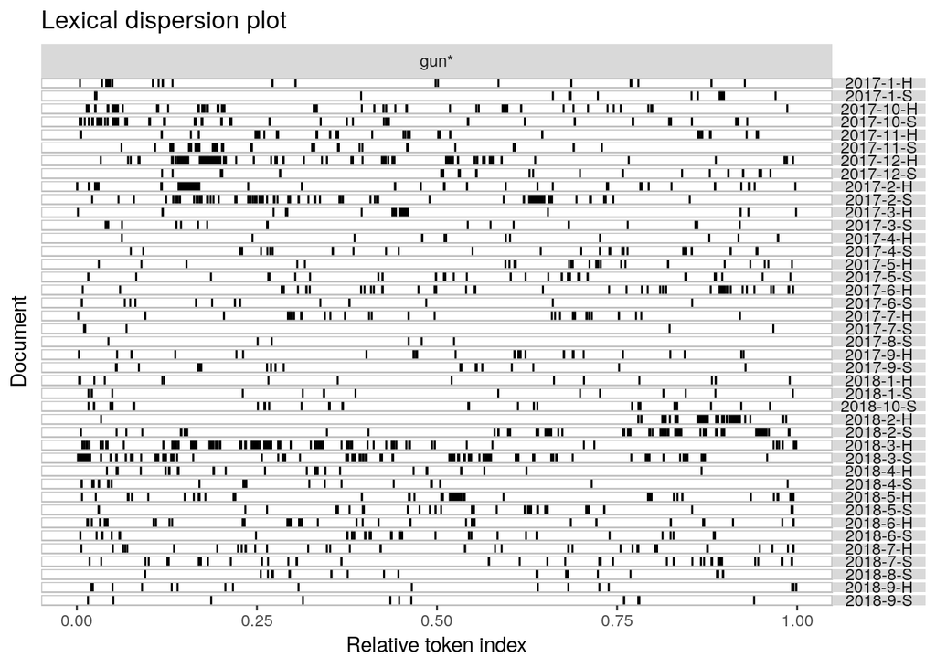

```r
quanteda::textplot_xray(kwic(aggregate115, "gun*", window = 5, valuetype = "glob"))
```

**Advanced** To make the previous plot a bit nicer, order the aggregated texts by year, month, chamber. To do this, you would need to modify the ordering of levels in the `aggregate115` dataset.

```r
# Let us start from automatically creating the levels of text name
years <- rep(rep(c("2017", "2018"), times = c(12,11)), times = 2)
months <- rep(as.character(seq(1,12)), times = 2)
# Remove the last element as we don't have data for December 2018
months <- rep(months[-length(months)], times = 2)
chamber <- rep(c("H", "S"), each = 23)
# As Map() returns list we need to flatten it into vector
lev <- unlist(Map(function(x, y, z) paste(x, y, z, sep = "-"), years, months, chamber))

aggregate115 <- congress115 %>%
  dplyr::mutate(year = as.character(lubridate::year(date)),
                month = as.character(lubridate::month(date)),
                year_month_chamber = paste(year, month, chamber, sep = "-")) %>%
  dplyr::mutate(year_month_chamber = factor(year_month_chamber,
                                            levels = lev)) %>%
  dplyr::group_by(year_month_chamber) %>%
  dplyr::summarise(text = paste(text, collapse = " "))

aggregate115 <- quanteda::corpus(aggregate115,
                                 docid_field = "year_month_chamber")
```

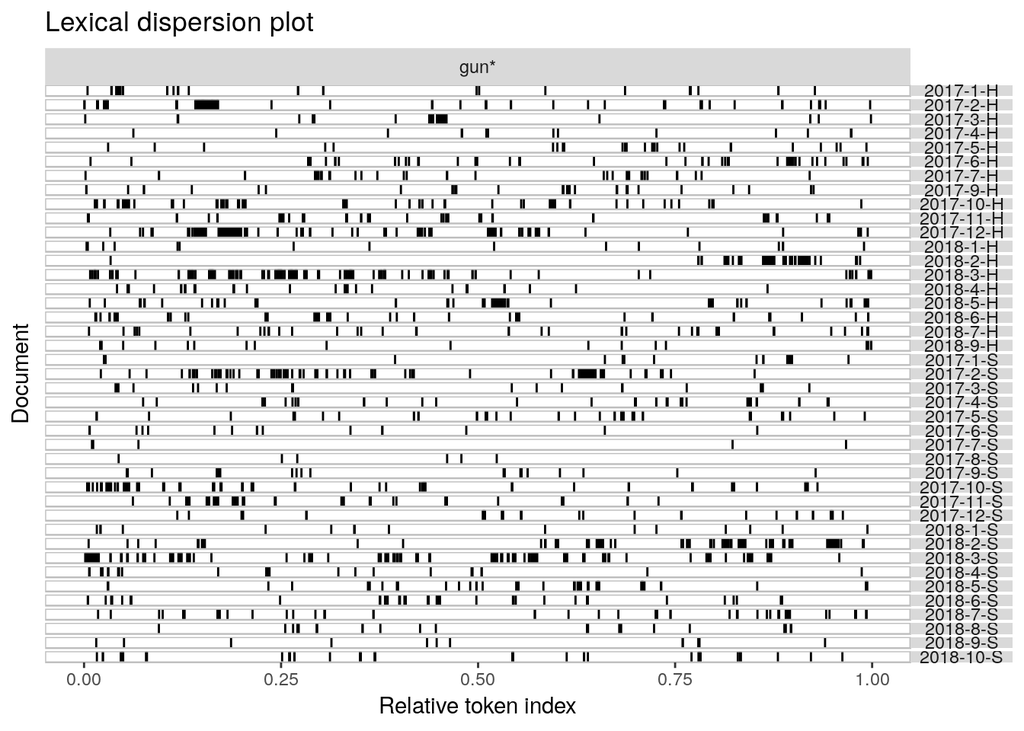

```r
quanteda::textplot_xray(kwic(aggregate115, "gun*", window = 5, valuetype = "glob"))
```

The gun debate, seemingly, intensified around February-March 2018 in both chambers, in the aftermath of the number of school shootings. While Las Vegas shooting in October 2017 saw a spike in frequency of references to guns in Congress, it was less prominent than the one in early 2018.

**Subject Expert** Create a dictionary related to gun violence and firearms control and apply to Congress debates.